# Text Processing / Feature Engeneering

Petro Tolochko

### Required Packages

```r
library(tm)
library(tidyverse)
library(ggthemes)
library(ggrepel)
```

# Stop words and other preprocessing effects

```r
getwd()
```

```
## [1] "/Users/petrotolochko/Desktop/Teaching/CEU_text_analysis_25/meeting_4"
```

```r
setwd("~/Desktop/teaching/CEU_text_analysis_25/meeting_4/")

# this is an example, paste your path here
```

Load the data:

```r
federalist <- read_csv("federalist.csv")
```

### Basic Pre-processing

```r
clean_federalist <- federalist %>%
  mutate(                           # the mutate() function is part of dplyr package / allows to change stuff within the dataframe easily
    text   = str_to_lower(text),                # turn all letters to lowercase
    text   = str_replace_all(text, "\n", " "),  # replace '/n' carriage return symbols
    text   = str_remove_all(text, "[:punct:]"), # remove all punctuation
    man    = str_count(text, "\\Wman "),        # Basic regex (more about it later in the course. '\\W' part means at the begging of the word) and count those up
    by     = str_count(text, "\\Wby "),         # same
    upon   = str_count(text, "\\Wupon ")        # same
  ) %>%
  rowwise() %>%                                 # make future functions work rowwise
  mutate(
    length = length(str_split(text, " ")[[1]])  # calculate the length of the text (in words)
  )
```

What are the most used words in the federalist papers?

```r
dtm_federalist <- DocumentTermMatrix(clean_federalist$text,
                                     control = list(removePunctuation = TRUE,
                                         stopwords = FALSE))

dtm_federalist <- dtm_federalist %>% as.matrix()

dim(dtm_federalist)
```

```
## [1]   85 8705
```

```r
most_frequent <- dtm_federalist %>% colSums()


most_frequent_df <- most_frequent %>% as.list() %>% as_tibble() %>%
  pivot_longer(everything())

most_frequent_df %>% arrange(desc(value))
```

```
## # A tibble: 8,705 × 2
##    name  value
##    <chr> <dbl>
##  1 the   17738
##  2 and    5079
##  3 that   2787
##  4 which  2061
##  5 this   1409
##  6 would  1277
##  7 have   1258
##  8 will   1250
##  9 for    1232
## 10 not    1213
## # ℹ 8,695 more rows
```

```r
most_frequent_df %>% arrange(desc(value)) %>% print(n = 50)
```

```
## # A tibble: 8,705 × 2
##    name         value
##    <chr>        <dbl>
##  1 the          17738
##  2 and           5079
##  3 that          2787
##  4 which         2061
##  5 this          1409
##  6 would         1277
##  7 have          1258
##  8 will          1250
##  9 for           1232
## 10 not           1213
## 11 their         1095
## 12 with          1048
```

[output cut: 39 more lines]

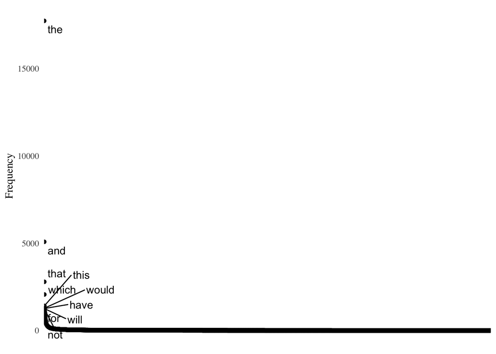

```r
most_frequent_df %>%
  mutate(label = ifelse(value > 1200, name, NA)) %>%
  ggplot() +
  geom_point(aes(reorder(name, -value),  value)) +
  geom_text_repel(aes(reorder(name, -value),  value, label = label),
                  max.overlaps = 20) +
  theme_tufte() +
  ylab("Frequency") +
  theme(
    axis.text.x = element_blank(),
    axis.title.x = element_blank(),
    axis.ticks = element_blank()
  )
```

Zipf’s Law (for many types of data studied in the physical and social sciences, the rank-frequency distribution is an inverse relation):

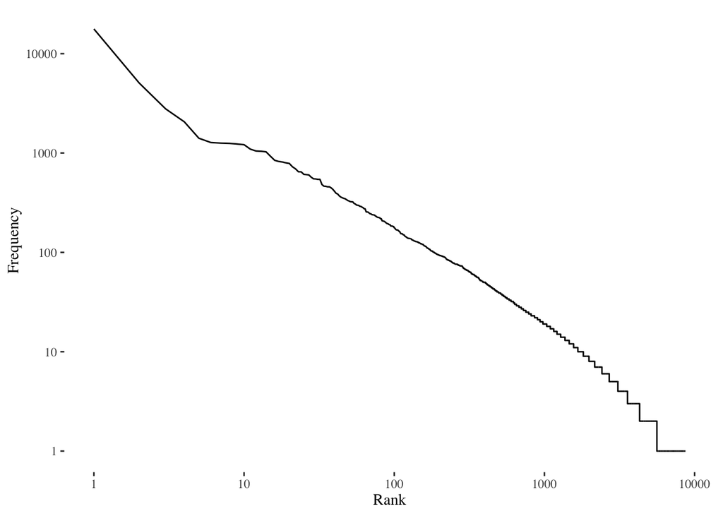

```r
most_frequent_df %>%
  arrange(desc(value)) %>%
  mutate(rank = 1:nrow(.)) %>%
  ggplot(aes(rank, value)) +
  geom_line() +
  ylab("Frequency") +
  xlab("Rank") +
  scale_x_log10() +
  scale_y_log10() +
  theme_tufte()
```

Not amazing.

What if we remove the “basic” stop-words?

```r
dtm_federalist <- DocumentTermMatrix(clean_federalist$text,
                                     control = list(removePunctuation = TRUE,
                                         stopwords = TRUE))

dtm_federalist <- dtm_federalist %>% as.matrix()

dim(dtm_federalist)
```

```
## [1]   85 8607
```

```r
most_frequent <- dtm_federalist %>% colSums()

most_frequent_df <- most_frequent %>% as.list() %>% as_tibble() %>%
  pivot_longer(everything())

most_frequent_df %>% arrange(desc(value))
```

```
## # A tibble: 8,607 × 2
##    name         value
##    <chr>        <dbl>
##  1 will          1250
##  2 states         844
##  3 government     823
##  4 may            812
##  5 state          786
##  6 people         610
##  7 power          606
##  8 one            543
##  9 can            464
## 10 constitution   462
## # ℹ 8,597 more rows
```

```r
# select only the words that start with an "a"

most_frequent_df %>% filter(str_detect(name, "^ani")) %>% arrange(desc(value)) %>%
  print(n = 100)
```

```
## # A tibble: 9 × 2
##   name          value
##   <chr>         <dbl>
## 1 animosities      10
## 2 animosity         6
## 3 animadversion     4
## 4 animated          2
## 5 animal            2
## 6 animals           2
## 7 animates          2
## 8 animating         1
## 9 animate           1
```

```r
most_frequent_df %>%
  mutate(stem = stemDocument(name)) %>%
  filter(str_detect(stem, "^ani")) %>%
  print(n = nrow(.))
```

```
## # A tibble: 9 × 3
##   name          value stem
##   <chr>         <dbl> <chr>
## 1 animosity         6 animos
## 2 animosities      10 animos
## 3 animated          2 anim
## 4 animal            2 anim
## 5 animals           2 anim
## 6 animating         1 anim
## 7 animadversion     4 animadvers
## 8 animates          2 anim
## 9 animate           1 anim
```

Already looking a little better!

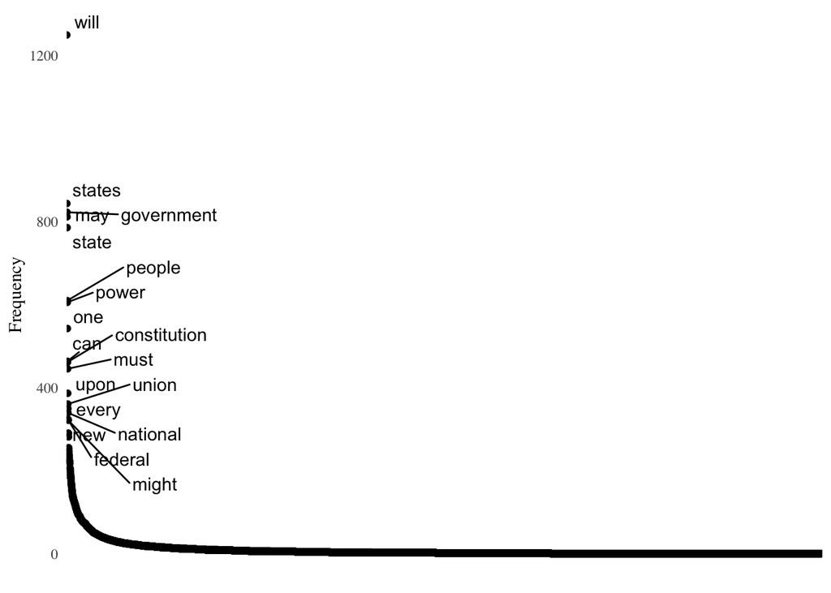

```r
most_frequent_df %>%
  mutate(label = ifelse(value > 300, name, NA)) %>%
  ggplot() +
  geom_point(aes(reorder(name, -value),  value)) +
  geom_text_repel(aes(reorder(name, -value),  value, label = label),
                  max.overlaps = 20) +
  theme_tufte() +
  ylab("Frequency") +
  theme(
    axis.text.x = element_blank(),
    axis.title.x = element_blank(),
    axis.ticks = element_blank()
  )
```

```r
most_frequent_df %>%
  arrange(desc(value)) %>%
  print(n = 100)
```

```
## # A tibble: 8,607 × 2
##     name            value
##     <chr>           <dbl>
##   1 will             1250
##   2 states            844
##   3 government        823
##   4 may               812
##   5 state             786
##   6 people            610
##   7 power             606
##   8 one               543
##   9 can               464
##  10 constitution      462
##  11 must              446
##  12 upon              387
```

[output cut: 89 more lines]

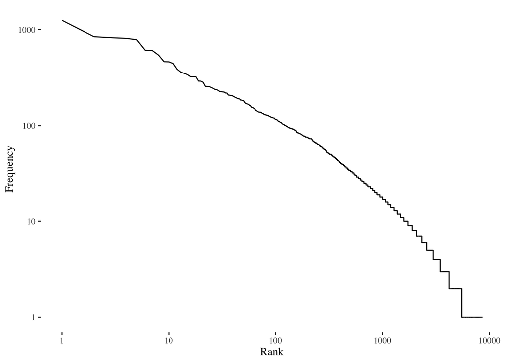

```r
most_frequent_df %>%
  arrange(desc(value)) %>%
  mutate(rank = 1:nrow(.)) %>%
  ggplot(aes(rank, value)) +
  geom_line() +
  ylab("Frequency") +
  xlab("Rank") +
  scale_x_log10() +
  scale_y_log10() +
  theme_tufte()
```

# What about stemming?

```r
# install.packages("SnowballC")
library(SnowballC)

# Example: Apply stemming via the 'stemDocument' function in a corpus/dtm workflow

# This does not work properly (the "ani" words are not stemmed properly):
# stemmed_corpus <- VCorpus(VectorSource(clean_federalist$text)) %>%
#   tm_map(stemDocument)


# This works (add stemming=TRUE to the control list):
dtm_stemmed <- DocumentTermMatrix(clean_federalist$text,
  control = list(stopwords = TRUE,
                 removePunctuation = TRUE,
                 stemming = TRUE)
)

dtm_stemmed <- as.matrix(dtm_stemmed)


dim(dtm_federalist)
```

```
## [1]   85 8607
```

```r
dim(dtm_stemmed)
```

```
## [1]   85 4941
```

```r
dtm_stemmed <- dtm_stemmed %>% as.matrix()


most_frequent_stemmed <- dtm_stemmed %>% colSums()



most_frequent_df_stemmed <- most_frequent_stemmed %>% as.list() %>% as_tibble() %>%
  pivot_longer(everything())

most_frequent_df_stemmed %>% arrange(desc(value))
```

```
## # A tibble: 4,941 × 2
##    name      value
##    <chr>     <dbl>
##  1 state      1654
##  2 will       1269
##  3 govern     1033
##  4 power       911
##  5 may         812
##  6 constitut   690
##  7 peopl       610
##  8 nation      566
##  9 one         552
## 10 can         464
## # ℹ 4,931 more rows
```

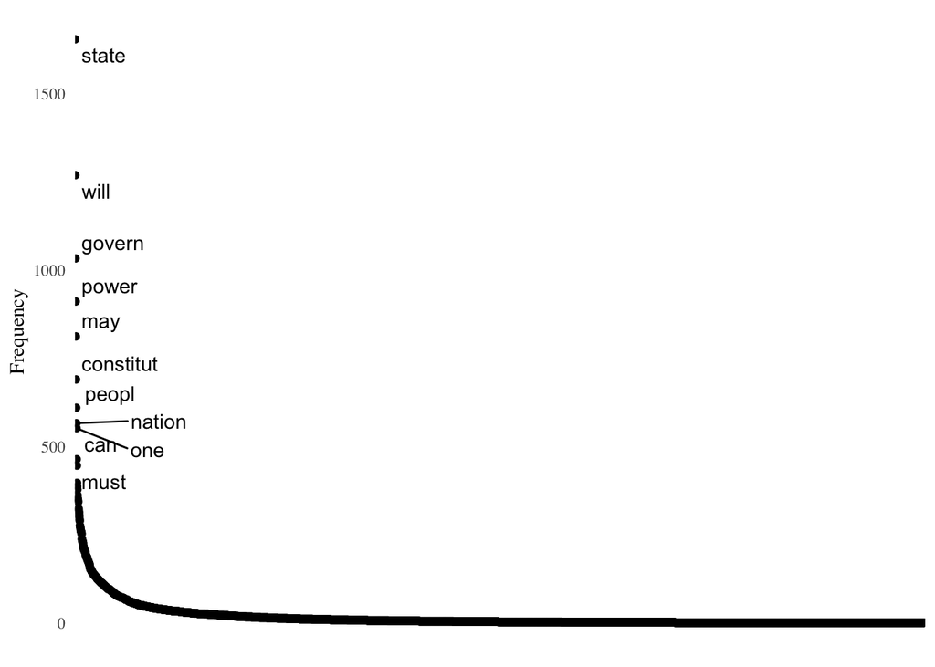

```r
most_frequent_df_stemmed %>%
  mutate(label = ifelse(value > 400, name, NA)) %>%
  ggplot() +
  geom_point(aes(reorder(name, -value),  value)) +
  geom_text_repel(aes(reorder(name, -value),  value, label = label),
                  max.overlaps = 20) +
  theme_tufte() +
  ylab("Frequency") +
  theme(
    axis.text.x = element_blank(),
    axis.title.x = element_blank(),
    axis.ticks = element_blank()

  )
```

# Bigrams

```r
# A simple base R function for extracting n-grams from a single string.
ngrams <- function(text, n = 2) {
  # 1) Split the text into tokens (splitting by whitespace here)
  tokens <- unlist(strsplit(text, "\\s+"))

  # If there aren't enough tokens, return an empty vector
  if (length(tokens) < n) return(character(0))

  # 2) Create a character vector for the n-grams
  out <- character(length(tokens) - n + 1)

  # 3) For each position, paste together 'n' consecutive tokens
  for (i in seq_along(out)) {
    out[i] <- paste(tokens[i:(i+n-1)], collapse = " ")
  }

  # Return the resulting n-grams
  return(out)
}

# Example usage:
example_text <- "Hello this is a short example sentence for demonstration"
ngrams(example_text, n = 2)
```

```
## [1] "Hello this"        "this is"           "is a"
## [4] "a short"           "short example"     "example sentence"
## [7] "sentence for"      "for demonstration"
```

```r
ngrams(example_text, n = 3)
```

```
## [1] "Hello this is"              "this is a"
## [3] "is a short"                 "a short example"
## [5] "short example sentence"     "example sentence for"
## [7] "sentence for demonstration"
```

# Bigrams (Tidytext Implementation)

For more information on the Tidytext approach, please refer to the [Tidytext book](https://www.tidytextmining.com/).

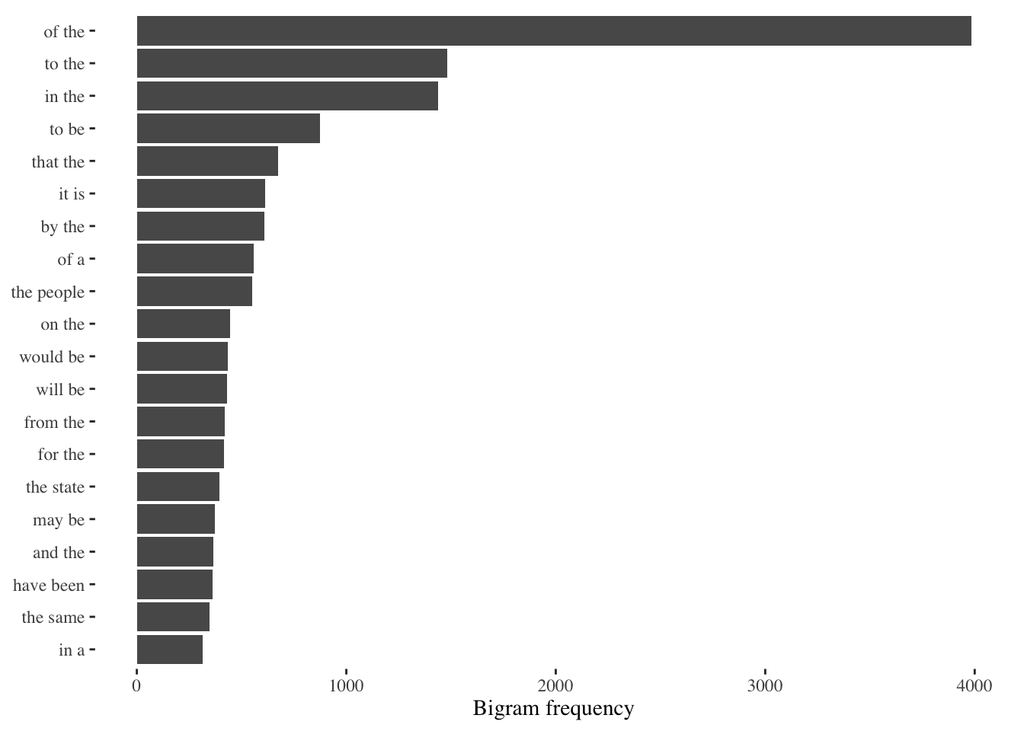

```r
# install.packages("tidytext")
library(tidytext)


test_df <- clean_federalist %>%
  unnest_tokens(unigrams, text, token = "ngrams", n = 30)

federalist_bigrams <- clean_federalist %>%
  unnest_tokens(bigram, text, token = "ngrams", n = 2) %>%
  count(bigram, sort = TRUE)


federalist_bigrams %>%
  group_by() %>%
  slice_max(n, n = 20) %>%
  ggplot(aes(x = reorder(bigram, n), y = n)) +
  geom_col() +
  coord_flip() +
  labs(x = NULL, y = "Bigram frequency") +
  theme_tufte()
```

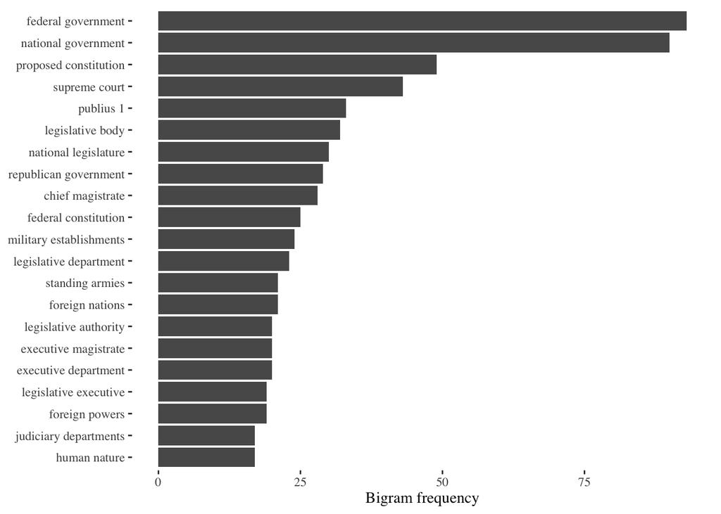

```r
# remove stopwords

data(stop_words)

federalist_bigrams_separated <- federalist_bigrams %>%
  separate(bigram, into = c("word1", "word2"), sep = " ")


federalist_bigrams_filtered <- federalist_bigrams_separated %>%
  filter(!word1 %in% stop_words$word,
         !word2 %in% stop_words$word)

federalist_bigrams_counts <- federalist_bigrams_filtered %>%
  unite("bigram", word1, word2, sep = " ")

# Now let's plot the top bigrams
federalist_bigrams_counts %>%
  slice_max(n, n = 20) %>%
  ggplot(aes(x = reorder(bigram, n), y = n)) +
  geom_col() +
  coord_flip() +
  labs(x = NULL, y = "Bigram frequency") +
  theme_tufte()
```

```r
# Per Author bigrams
```

# TFIDF

$$W_{ij} \times log\frac{N}{n_j}$$

Super easy, actually. There’s already a function implemented in the `tm` package. It’s called `weightTfIdf`, and we should pass it to the control param of the `DocumentTermMatrix` function:

```r
dtm_federalist <- DocumentTermMatrix(clean_federalist$text,
                                     control = list(removePunctuation = TRUE,
                                         stopwords = TRUE))

dtm_federalist_tfidf <- weightTfIdf(dtm_federalist)


dtm_federalist_tfidf <- dtm_federalist_tfidf %>% as.matrix()

dim(dtm_federalist_tfidf)
```

```
## [1]   85 8607
```

```r
most_frequent <- dtm_federalist_tfidf %>% colSums()

most_frequent_df <- most_frequent %>% as.list() %>% as_tibble() %>%
  pivot_longer(everything())

most_frequent_df %>% arrange(desc(value)) %>% print(n = 50)
```

```
## # A tibble: 8,607 × 2
##    name            value
##    <chr>           <dbl>
##  1 senate          0.266
##  2 executive       0.248
##  3 president       0.235
##  4 courts          0.230
##  5 representatives 0.208
##  6 upon            0.199
##  7 court           0.180
##  8 elections       0.179
##  9 militia         0.166
## 10 legislative     0.160
## 11 judiciary       0.159
## 12 nations         0.159
```

[output cut: 39 more lines]

Not bad… Let’s plot this:

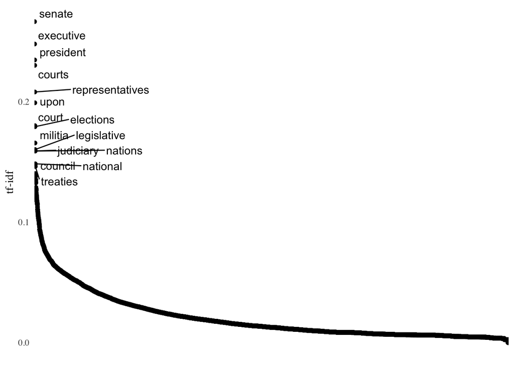

```r
most_frequent_df %>%
  mutate(label = ifelse(value > .107, name, NA)) %>%
  ggplot() +
  geom_point(aes(reorder(name, -value),  value)) +
  geom_text_repel(aes(reorder(name, -value),  value, label = label),
                  max.overlaps = 20) +
  theme_tufte() +
  ylab("tf-idf") +
  theme(
    axis.text.x = element_blank(),
    axis.title.x = element_blank(),
    axis.ticks = element_blank()

  )
```

# Log Odds

First, let’s see if `tfidf` can be a good discriminant function between `Hamilton` and `Madison`?

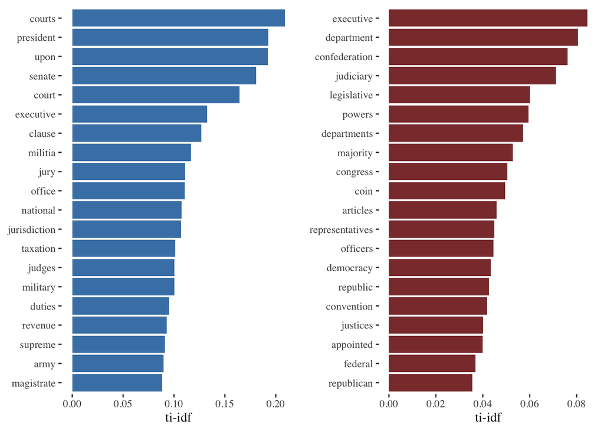

```r
dtm_federalist <- DocumentTermMatrix(clean_federalist$text,
                                     control = list(removePunctuation = TRUE,
                                         stopwords = TRUE))

dtm_federalist_tfidf <- weightTfIdf(dtm_federalist)

hamilton_ids <- which(clean_federalist$author == "HAMILTON")
madison_ids <- which(clean_federalist$author == "MADISON")

most_frequent_hamilton <- dtm_federalist_tfidf[hamilton_ids, ] %>%
  as.matrix() %>% colSums()
most_frequent_madison <- dtm_federalist_tfidf[madison_ids, ] %>%
  as.matrix() %>% colSums()



most_frequent_df_hamilton <- most_frequent_hamilton %>%
  as.list() %>%
  as_tibble() %>%
  pivot_longer(everything()) %>%
  mutate(author = "HAMILTON")


most_frequent_df_madison <- most_frequent_madison %>%
  as.list() %>%
  as_tibble() %>%
  pivot_longer(everything()) %>%
  mutate(author = "MADISON")

most_frequent_df <- bind_rows(most_frequent_df_hamilton,
                              most_frequent_df_madison)

hamilton_plot <- most_frequent_df %>%
  filter(author == "HAMILTON") %>%
  top_n(20, value) %>%
  ggplot() +
  geom_bar(aes(reorder(name, value), value),
           stat = "identity",
           fill = "steelblue") +
  coord_flip() +
  ylab("ti-idf") +
  theme_tufte() +
  theme(axis.title.y = element_blank())

madison_plot <- most_frequent_df %>%
  filter(author == "MADISON") %>%
  top_n(20, value) %>%
  ggplot() +
  geom_bar(aes(reorder(name, value), value),
           stat = "identity",
           fill = "indianred4") +
  coord_flip() +
  ylab("ti-idf") +
  theme_tufte() +
  theme(axis.title.y = element_blank())


cowplot::plot_grid(hamilton_plot, madison_plot,
                   ncol = 2)
```

Let’s try to calculate log odds.

$$logO^i_w = log\frac{f^i_w}{1 - f^i_w}$$

```r
# Original DTM
dtm_federalist <- DocumentTermMatrix(clean_federalist$text,
  control = list(removePunctuation = TRUE,
                 stopwords = TRUE)
)

# Identify HAMILTON and MADISON docs
hamilton_ids <- which(clean_federalist$author == "HAMILTON")
madison_ids  <- which(clean_federalist$author == "MADISON")

# Convert the entire DTM to a matrix for easy column sums
dtm_mat <- as.matrix(dtm_federalist)
word_counts <- colSums(dtm_mat)

# 1) Filter out extremely rare words
#    e.g., words that appear fewer than 5 times overall
rare_threshold <- 5
keep_words <- names(word_counts)[word_counts >= rare_threshold]

dtm_federalist <- dtm_federalist[ , keep_words]
dtm_mat        <- dtm_mat[ , keep_words]  # re-assign the filtered matrix

# Recompute word counts after filtering
word_counts <- colSums(dtm_mat)


dtm_federalist  <- dtm_federalist  %>% as.matrix()

dtm_hamilton <- dtm_federalist[hamilton_ids, ] %>%
  colSums()

dtm_madison <- dtm_federalist[madison_ids, ] %>%
  colSums()

# Laplace smoothing with +1
freq_ham <- (dtm_hamilton + 1) / sum(dtm_hamilton + 1)
freq_mad <- (dtm_madison  + 1) / sum(dtm_madison  + 1)

# Log-odds function
log_odds <- function(p) log(p / (1 - p))

log_odds_ham <- log_odds(freq_ham)
log_odds_mad <- log_odds(freq_mad)

log_odds_ratio <- log_odds_ham - log_odds_mad  # difference in log-odds

log_odds_ratio <- enframe(log_odds_ratio, name = "word", value = "log_odds_diff")

# Bring in overall frequency of each word
general_frequency <- enframe(word_counts, name = "word", value = "freq")

log_odds_ratio <- log_odds_ratio %>%
  left_join(general_frequency, by = "word")
```

Now, log odds ratio:

$$log\frac{O^i_w}{O^j_w} = log\frac{f^i_w}{1 - f^i_w}/\frac{f^j_w}{1 -
f^j_w} = log\frac{f^i_w}{1 - f^i_w} - log\frac{f^j_w}{1 - f^j_w}$$

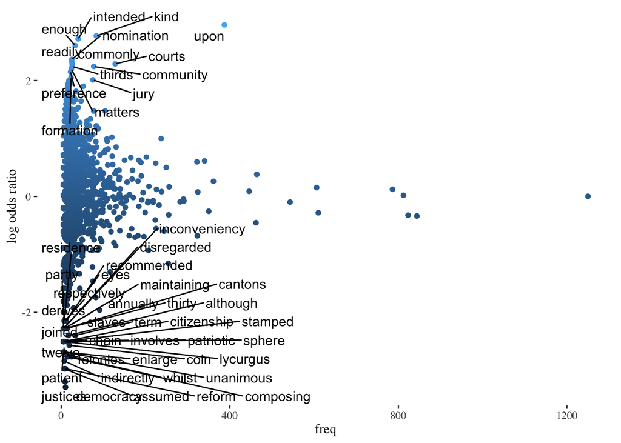

```r
log_odds_ratio %>%
  mutate(label = ifelse(log_odds_diff > 2 | log_odds_diff < -2, word, NA)) %>%
  ggplot() +
  geom_point(aes(freq, log_odds_diff, color = log_odds_diff)) +
  geom_text_repel(aes(freq, log_odds_diff, label = label),
                  max.overlaps = 50) +
  ylab("log odds ratio") +
  theme_tufte() +
  theme(legend.position = "none")
```

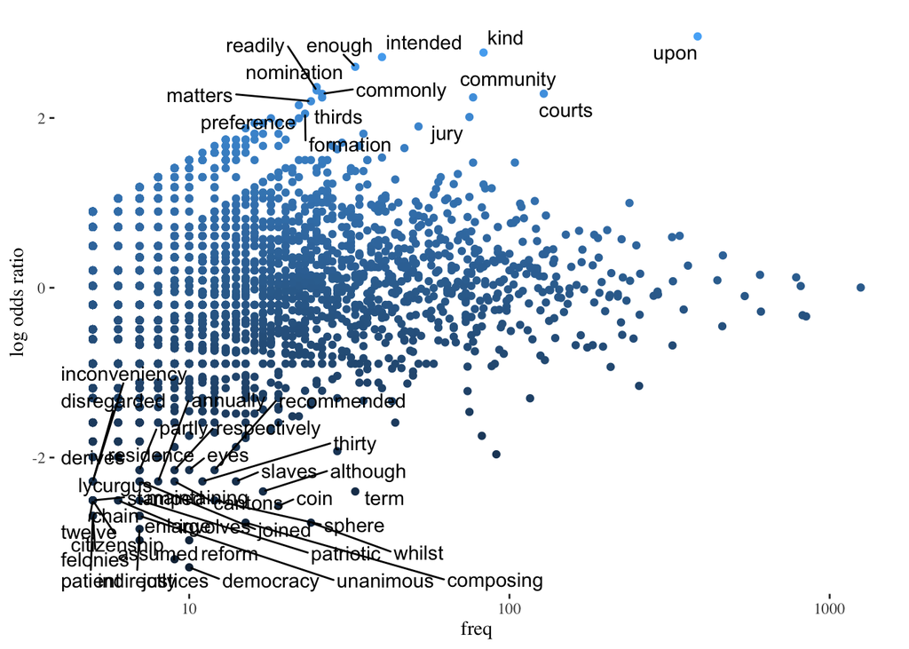

```r
log_odds_ratio %>%
  mutate(label = ifelse(log_odds_diff > 2 | log_odds_diff < -2, word, NA)) %>%
  ggplot() +
  geom_point(aes(freq, log_odds_diff, color = log_odds_diff)) +
  geom_text_repel(aes(freq, log_odds_diff, label = label),
                  max.overlaps = 50) +
  ylab("log odds ratio") +
  scale_x_log10() +  # often helpful to log-scale the frequency axis
  theme_tufte() +
  theme(legend.position = "none")
```

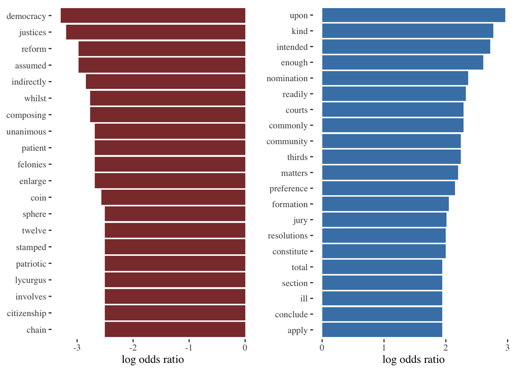

```r
hamilton_plot <- log_odds_ratio %>%
  top_n(20, log_odds_diff) %>%
  ggplot() +
  geom_bar(aes(reorder(word, log_odds_diff), log_odds_diff),
           stat = "identity",
           fill = "steelblue") +
  coord_flip() +
  ylab("log odds ratio") +
  theme_tufte() +
  theme(axis.title.y = element_blank())

madison_plot <- log_odds_ratio %>%
  top_n(20, -log_odds_diff) %>%
  ggplot() +
  geom_bar(aes(reorder(word, -log_odds_diff), log_odds_diff),
           stat = "identity",
           fill = "indianred4") +
  coord_flip() +
  ylab("log odds ratio") +
  theme_tufte() +
  theme(axis.title.y = element_blank())


cowplot::plot_grid(madison_plot, hamilton_plot,
                   ncol = 2)
```

# Fightin’ Words

There are many problems with this method. Please refer to **Fightin’ Words: Lexical Feature Selection and Evaluation for Identifying the Content of Political Conflict** by **Monroe**, **Colaresi** & **Quinn** (2009) for a very cool overview and improvement on the method.

This approach refines the basic log-odds comparison by introducing a Bayesian perspective with a Dirichlet prior, allowing for both posterior estimates of word usage and *z*‐scores of the difference. This helps identify the **most distinctly used** words between two groups (e.g., Hamilton vs. Madison).

## Mathematical Formulation

Let:

- $c_{1,w}$ be the count of word $w$ in group 1 (e.g., Hamilton),
- $c_{2,w}$ be the count of word $w$ in group 2 (e.g., Madison),
- $\alpha$ be a small prior hyperparameter (e.g., 0.01),
- $V$ be the total number of distinct words (the vocabulary size).

### 1. Posterior Proportions

We assume a Dirichlet prior on the probability of each word within each group. The posterior estimate of word $w$ in group $g$ ($g \in \{1,2\}$) is:

$$\hat{p}_{g,w}
=
\frac{c_{g,w} + \alpha}{\sum_{w} c_{g,w} + \alpha \, V}.$$

### 2. Difference in Log-Odds

Convert each posterior proportion to **log-odds**:

$$\text{log_odds}_{g,w}
=
\ln\!\Bigl(\frac{\hat{p}_{g,w}}{1 - \hat{p}_{g,w}} \Bigr),$$

and then compute the difference:

$$\Delta_w
=
\text{log_odds}_{1,w}
\;-\;
\text{log_odds}_{2,w}.$$

### 3. Approximate Variance and *z*‐score

An approximate variance for $\Delta_w$ under the Dirichlet–Multinomial model is given by:

$$\mathrm{Var}(\Delta_w)
\approx
\frac{1}{c_{1,w} + \alpha}
+
\frac{1}{\Bigl(\sum_{w} c_{1,w} + \alpha \, V\Bigr) - \bigl(c_{1,w}
+ \alpha\bigr)}
+
\frac{1}{c_{2,w} + \alpha}
+
\frac{1}{\Bigl(\sum_{w} c_{2,w} + \alpha \, V\Bigr) - \bigl(c_{2,w}
+ \alpha\bigr)}.$$

Thus, we can define a *z*‐score for the difference:

$$z_w
=
\frac{\Delta_w}{\sqrt{\mathrm{Var}(\Delta_w)}}.$$

Words with large positive $\Delta_w$ (and large $|z_w|$) are highly indicative of group 1; words with large negative $\Delta_w$ are more characteristic of group 2.

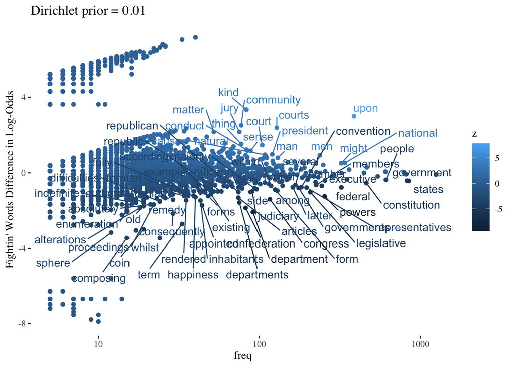

```r
dtm_hamilton <- dtm_federalist[hamilton_ids, ] %>%
  colSums()

dtm_madison <- dtm_federalist[madison_ids, ] %>%
  colSums()

# Laplace smoothing with +1
freq_ham <- (dtm_hamilton + 1) / sum(dtm_hamilton + 1)
freq_mad <- (dtm_madison  + 1) / sum(dtm_madison  + 1)

# Log-odds function
log_odds <- function(p) log(p / (1 - p))

log_odds_ham <- log_odds(freq_ham)
log_odds_mad <- log_odds(freq_mad)

log_odds_ratio <- log_odds_ham - log_odds_mad  # difference in log-odds

log_odds_ratio <- enframe(log_odds_ratio, name = "word", value = "log_odds_diff")

# Bring in overall frequency of each word
general_frequency <- enframe(word_counts, name = "word", value = "freq")




fightin_words_log_odds <- function(c1, c2, alpha = 0.01) {
  # c1, c2: named integer vectors of word counts for group 1 and group 2
  # alpha : Dirichlet prior hyperparameter

  # Make sure c1, c2 have same names (same vocab)
  stopifnot(all(names(c1) == names(c2)))

  V <- length(c1)

  n1 <- sum(c1)
  n2 <- sum(c2)

  # Posterior proportions for group 1 and group 2
  p1 <- (c1 + alpha) / (n1 + alpha * V)
  p2 <- (c2 + alpha) / (n2 + alpha * V)

  # log-odds
  log_odds_1 <- log(p1 / (1 - p1))
  log_odds_2 <- log(p2 / (1 - p2))

  d <- log_odds_1 - log_odds_2  # difference

  # Approx variance
  var_d <- 1 / (c1 + alpha) + 1 / (n1 - c1 + alpha * (V - 1)) +
           1 / (c2 + alpha) + 1 / (n2 - c2 + alpha * (V - 1))

  z <- d / sqrt(var_d)  # z-score

  tibble(
    word          = names(c1),
    log_odds_diff = d,
    z             = z
  )
}

# Example usage:
alpha_val <- 0.01  # small prior
res_fightin <- fightin_words_log_odds(
  c1 = dtm_hamilton,
  c2 = dtm_madison,
  alpha = alpha_val
)

# Merge in overall frequency
res_fightin <- res_fightin %>%
  left_join(general_frequency, by = "word")

# Now we can highlight words with large absolute z-scores or large log-odds
res_fightin %>%
  mutate(label = ifelse(abs(z) > 3, word, NA)) %>%
  ggplot(aes(freq, log_odds_diff, color = z)) +
  geom_point() +
  geom_text_repel(aes(label = label), max.overlaps = 50) +
  scale_x_log10() +
  ylab("Fightin' Words Difference in Log-Odds") +
  ggtitle(paste("Dirichlet prior =", alpha_val)) +
  theme_tufte() +
  theme(legend.position = "right")
```

# Text complexity

```r
my_ttr <- function(text) {
  tokens <- unlist(strsplit(text, "\\s+"))
  types <- length(unique(tokens))
  ttr <- types / length(tokens)
  return(ttr)
}

# Example usage on each row of `clean_federalist`
clean_federalist %>%
  mutate(TTR = sapply(text, my_ttr)) %>%
  group_by(author) %>%
  summarize(mean_TTR = mean(TTR), sd_TTR = sd(TTR))
```

```
## # A tibble: 5 × 3
##   author               mean_TTR sd_TTR
##   <chr>                   <dbl>  <dbl>
## 1 HAMILTON                0.331 0.0417
## 2 HAMILTON AND MADISON    0.393 0.0311
## 3 HAMILTON OR MADISON     0.312 0.0296
## 4 JAY                     0.352 0.0315
## 5 MADISON                 0.292 0.0320
```

# Semantic Networks

Modified example from the [Tidytext book](https://www.tidytextmining.com/).

```r
# install.packages("igraph")
# install.packages("ggraph")

require(igraph)
require(ggraph)
```

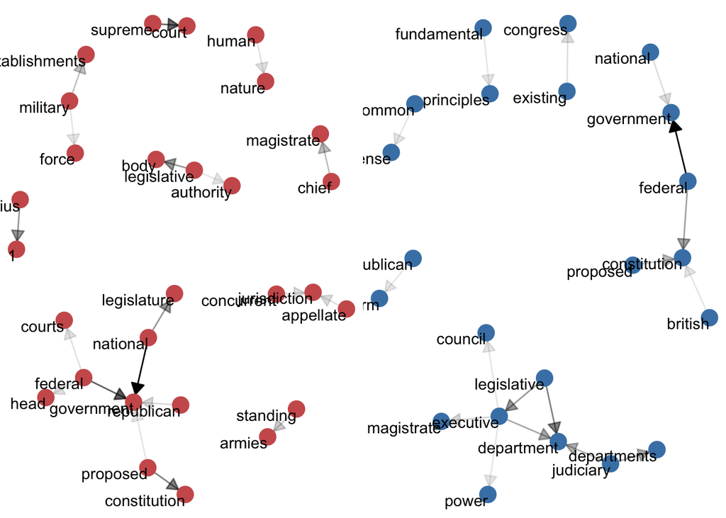

```r
federalist_bigrams <- clean_federalist %>%
  unnest_tokens(bigram, text, token = "ngrams", n = 2) %>%
  count(bigram, sort = TRUE)



# remove stopwords


groupped_bigrams <- clean_federalist %>%
  group_by(author) %>%
  unnest_tokens(bigram, text, token = "ngrams", n = 2) %>%
  count(bigram, sort = TRUE)

bigrams_separeted <- groupped_bigrams %>%
  separate(bigram, into = c("word1", "word2"), sep = " ")


bigrams_separeted_filtered <- bigrams_separeted %>%
  filter(!word1 %in% stop_words$word,
         !word2 %in% stop_words$word)


bigram_graph_ham <- bigrams_separeted_filtered %>%
  filter(author == "HAMILTON") %>%
  ungroup() %>%
  select(-author) %>%
  filter(n > 10) %>%
  graph_from_data_frame()

bigram_graph_mad <- bigrams_separeted_filtered %>%
  filter(author == "MADISON") %>%
  ungroup() %>%
  select(-author) %>%
  filter(n > 5) %>%
  graph_from_data_frame()



a <- grid::arrow(type = "closed", length = unit(.3, "cm"))

ham_graph <- ggraph(bigram_graph_ham, layout = "fr") +
  geom_edge_link(aes(edge_alpha = n), show.legend = FALSE,
                 arrow = a, end_cap = circle(.2, 'cm')) +
  geom_node_point(color = "indianred", size = 5) +
  geom_node_text(aes(label = name), vjust = 1, hjust = 1) +
  theme_void()

mad_graph <- ggraph(bigram_graph_mad, layout = "fr") +
  geom_edge_link(aes(edge_alpha = n), show.legend = FALSE,
                 arrow = a, end_cap = circle(.2, 'cm')) +
  geom_node_point(color = "steelblue", size = 5) +
  geom_node_text(aes(label = name), vjust = 1, hjust = 1) +
  theme_void()

# install.packages("cowplot")
library(cowplot)
plot_grid(ham_graph, mad_graph, ncol = 2)
```